# White wines’ quality classification with Logistic Regression

LJSSE

19/5/2021

[figure not shown]

# Introduction

The dataset **white_wines.csv** stores data about physicochemical properties of many white wines coming from the north-west region of Portugal, called Minho.

Each row refers to a wine, while each column contains a physicochemical property.  
Here we list the properties and their unit of measure:

- fixed acidity (FA: g(tartaric acid)/dm^3)
- volatile acidity (VA: g(acetic acid)/dm^3)
- citric acid (CA: g/dm^3)
- residual sugar (RS: g/dm^3)
- chlorides (CH: g(sodium chloride)/dm^3)
- free sulfur dioxide (FSD: mg/dm^3)
- total sulfur dioxide (TSD: mg/dm^3)
- density (DE: g/dm^3)
- pH
- sulphates (SU: g(potassium sulphate)/dm^3)
- alcohol (AL: %vol)
- *target*: quality (from 0 to 10)

The aim of this project will be to classify white wines according to their quality, labeling them as “low” if their quality score is from 0 to 5, and as “high” if the score is between 6 and 10.

# The data

First, we nedd to inspect the variables and make the suitable transformations, if necessary.

```
## 'data.frame':    4898 obs. of  12 variables:
##  $ fixed.acidity       : num  7 6.3 8.1 7.2 7.2 8.1 6.2 7 6.3 8.1 ...
##  $ volatile.acidity    : num  0.27 0.3 0.28 0.23 0.23 0.28 0.32 0.27 0.3 0.22 ...
##  $ citric.acid         : num  0.36 0.34 0.4 0.32 0.32 0.4 0.16 0.36 0.34 0.43 ...
##  $ residual.sugar      : num  20.7 1.6 6.9 8.5 8.5 6.9 7 20.7 1.6 1.5 ...
##  $ chlorides           : num  0.045 0.049 0.05 0.058 0.058 0.05 0.045 0.045 0.049 0.044 ...
##  $ free.sulfur.dioxide : num  45 14 30 47 47 30 30 45 14 28 ...
##  $ total.sulfur.dioxide: num  170 132 97 186 186 97 136 170 132 129 ...
##  $ density             : num  1.001 0.994 0.995 0.996 0.996 ...
##  $ pH                  : num  3 3.3 3.26 3.19 3.19 3.26 3.18 3 3.3 3.22 ...
##  $ sulphates           : num  0.45 0.49 0.44 0.4 0.4 0.44 0.47 0.45 0.49 0.45 ...
##  $ alcohol             : num  8.8 9.5 10.1 9.9 9.9 10.1 9.6 8.8 9.5 11 ...
##  $ quality             : int  6 6 6 6 6 6 6 6 6 6 ...
```

All the features are numeric, and are already stored in the right format.

## Defining the target

We re-encode “quality” as a factor with two levels, in order to make the target binary. We also specify the order of the levels, since the method to perform logistic regression takes the first level as the baseline, and we want to predict the probability of having a high quality wine.  
As we can see the two categories are unbalanced, with the data containing a higher proportion of “high” instances.

```
##
##  low high
## 1640 3258
```

In order to have a unique identifier for each wine, we also create an “id” variable.

# Data description

Before proceeding with our analysis, we perform some descriptive statistics in order to both understand the relations within the variables, and to visualize their distributions. This will help us to get a first idea of the relevance of the features for our classification task.

### Heatmap

First we plot the correlation matrix, in order to detect any strong relation among features which could lead to multicollinearity problems.

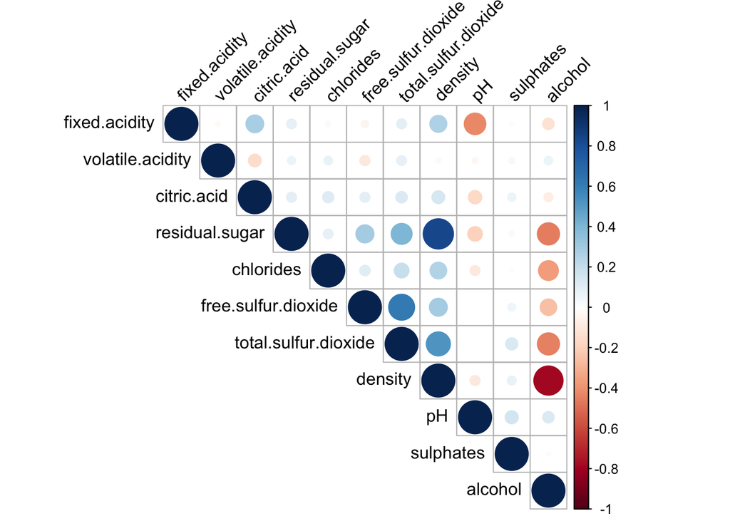

This plot highlights a strong correlation between density and two variables: residual.sugar and alcohol.

### Frequency polygons

To get an understanding of which variable should be excluded from the regression, we plot the histograms of the highly correlated variables identified above.

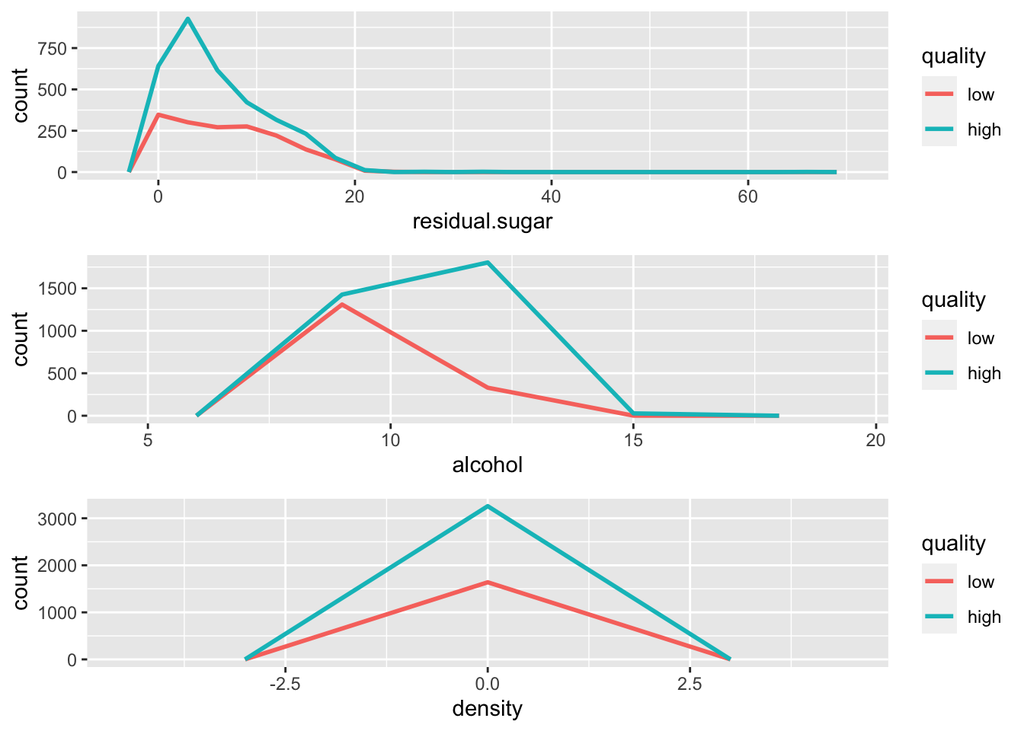

We decide to remove density.  
In fact, we can observe that for each value of density there is no difference in the distribution of quality, once we account for the numerosity of the two quality levels. On the other hand, the modal values for the other two variables differ for low and high quality wines, thus adding more useful information for the purpose of classification.

### Correlation with the target

It is also useful to compute the correlations between the covariates and the target, in order to see if there are any particularly powerful features that would make the task too trivial.  
In order to do so we exploit *biserial correlation*, which allows to compute a correlation index between a numerical and a binary variable.

```
##                      bicorrs
## citric.acid             0.00
## free.sulfur.dioxide     0.00
## sulphates              -0.05
## pH                     -0.08
## fixed.acidity           0.09
## residual.sugar          0.09
## total.sulfur.dioxide    0.17
## chlorides               0.18
## volatile.acidity        0.23
## alcohol                -0.38
```

Here the correlations are displayed in ascending absolute value, and we can observe that the variable showing the highest correlation value with wines quality is alcohol, meaning that alcohol is more correlated to wine quality compared to the other variables, but it is not too strong (-38%).

### Boxplots

We now look at the distribution of all the explanatory variables, in order to both visualize those values which are far from the bulk of the data, and to get an understanding of the variables displaying the most divergent median values among low and high quality wines.

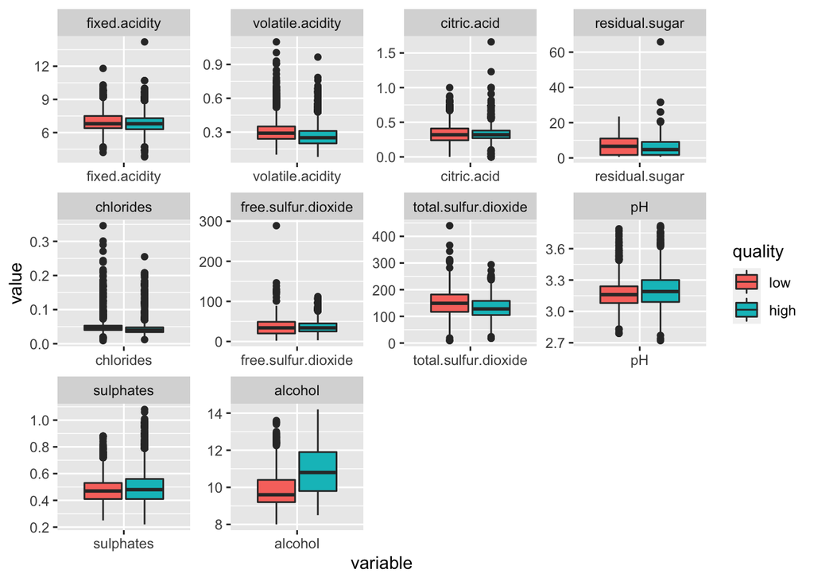

We can observe the following:

- The features displaying the highest median difference between high and low quality wines are “volatile.acidity”, “total.sulfur.dioxide”, “pH”, “alcohol.” Theese variables are candidates to be the significant ones in the regression framework.
- There are some outlying values. We will deal with them in the section below.

### Data splitting

In order to train and validate our model on different sets, we split the data, keeping 30% of it to carry out performance evaluation.

# Variables Selection

### Forward Stepwise Method

To find the main factors determining wine quality and to remove the unrelated ones, we use forward stepwsie method to do variable selection.  
The best subset of the model can be found by starting from a null model with no predictors, then picking the best p (p is the number of predictors in the full model) models which have exactly 1, 2, …, p predictors, and finally selecting the model with the lowest Bayesian information criterion (BIC) value.  
In our case, the inclusion of the variables follows the order of alcohol, volatile.acidity, residual.sugar, sulphates, fixed.acidity, free.sulfur.dioxide, total.sulfur.dioxide, pH, chlorides and citric.acid.  
When the model contains 6 variables, it has lowest BIC value. So, the variables of the optimal model are the six first ones.

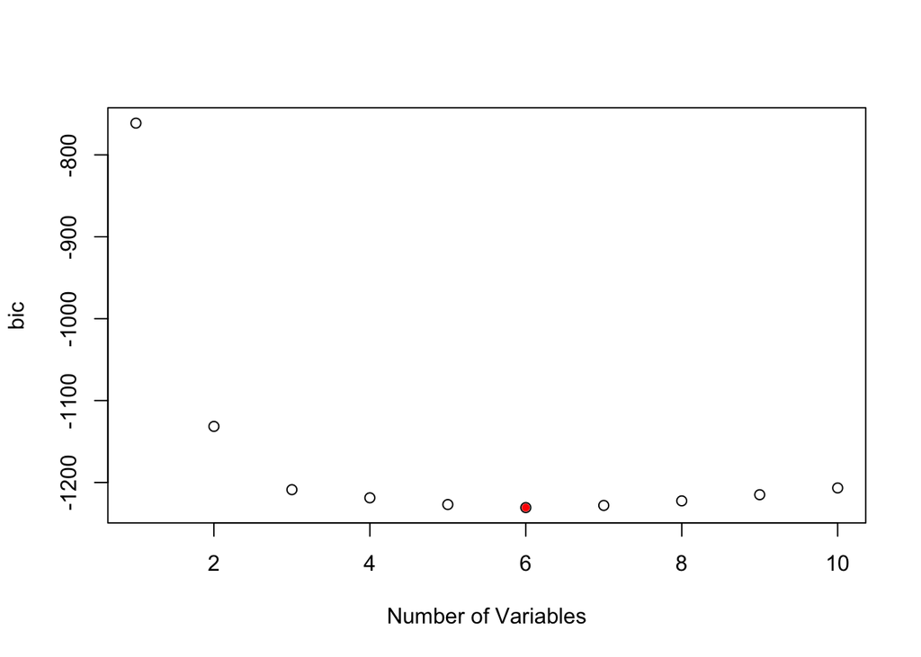

Optimal number of variables: 6.

We plot the results in order to visualize which variables have been selected with BIC in each model, and we highlight the optimal model with a yellow line.

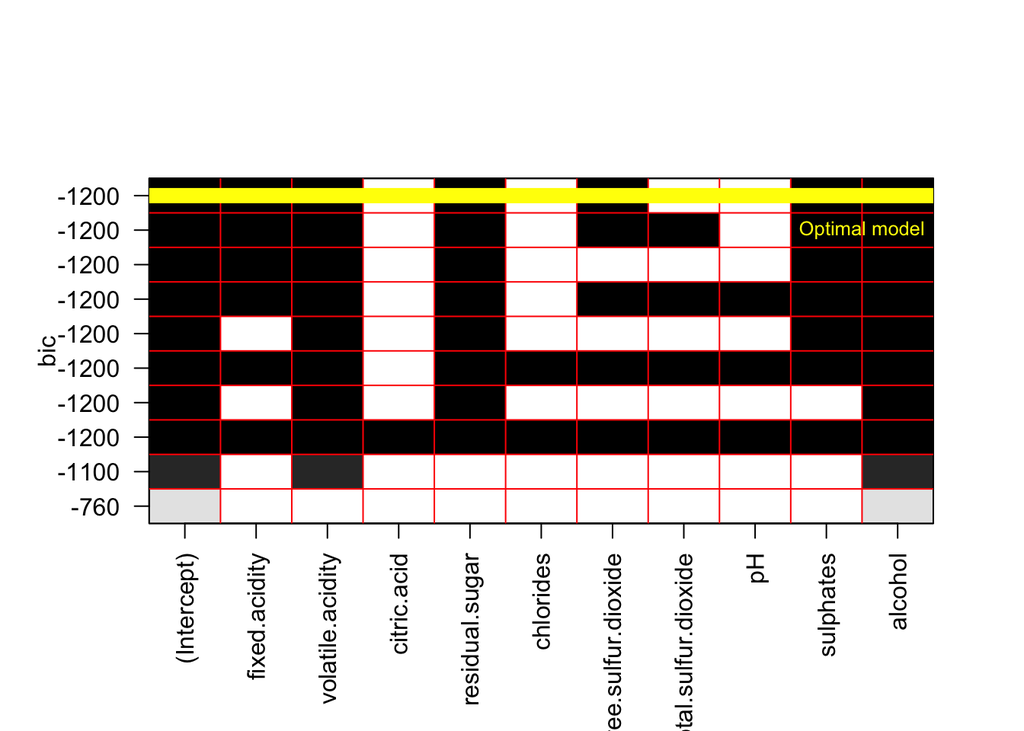

# Logistic Regression

Logistic Regression is now performed on the restricted model with the six selected variables:  
fixed.acidity, volatile.acidity, residual.sugar, free.sulfur.dioxide, sulphates, alcohol.

```
##
## Call:
## glm(formula = quality ~ ., family = binomial(link = "logit"),
##     data = dtrain.res[, -8])
##
## Deviance Residuals:
##     Min       1Q   Median       3Q      Max
## -3.2061  -0.9295   0.4421   0.8095   2.5943
##
## Coefficients:
##                      Estimate Std. Error z value Pr(>|z|)
## (Intercept)         -8.592428   0.684318 -12.556  < 2e-16 ***
## fixed.acidity       -0.199361   0.050535  -3.945 7.98e-05 ***
## volatile.acidity    -6.839886   0.475896 -14.373  < 2e-16 ***
## residual.sugar       0.069506   0.009266   7.501 6.31e-14 ***
## free.sulfur.dioxide  0.009151   0.002638   3.469 0.000522 ***
## sulphates            1.174704   0.397829   2.953 0.003149 **
## alcohol              1.087650   0.049613  21.923  < 2e-16 ***
## ---
## Signif. codes:  0 '***' 0.001 '**' 0.01 '*' 0.05 '.' 0.1 ' ' 1
##
## (Dispersion parameter for binomial family taken to be 1)
##
##     Null deviance: 4372.1  on 3428  degrees of freedom
## Residual deviance: 3473.9  on 3422  degrees of freedom
## AIC: 3487.9
##
## Number of Fisher Scoring iterations: 5
```

In order to make the coefficients interpretable in terms of odds ratios, we exponentiate them.

```
##                               OR        2.5 %       97.5 %
## (Intercept)         0.0001855052 4.792037e-05 0.0007012564
## fixed.acidity       0.8192544377 7.417640e-01 0.9043487172
## volatile.acidity    0.0010702254 4.167073e-04 0.0026921035
## residual.sugar      1.0719781194 1.052868e+00 1.0918265634
## free.sulfur.dioxide 1.0091927889 1.004017e+00 1.0144576187
## sulphates           3.2371838604 1.491538e+00 7.0985165733
## alcohol             2.9672915619 2.696374e+00 3.2754223381
```

The following variables are those significant at a 99% confidence level:

- *“Intercept”*: the decrease in the odds of having a high quality wine when all the explanatory variables are set to 0 is 99.98%.
- *“fixed.acidity”*: a unitary increase (1 g/dm^3) in fixed acidity will lead to a 18.1% decrease in the odds of having a high quality wine.
- *"volatile.acidity*": a unitary increase (1 g/dm^3) in volatile acidity will lead to a 99.89% decrease in the odds of having a high quality wine.
- *“residual.sugar”*: a unitary increase (1 g/dm^3) in residual sugar will lead to a 7.2% increase in the odds of having a high quality wine.
- *“free.sulfur.dioxide”*: a unitary increase (1 mg/dm^3) in free sulfur dioxide will lead to a 0.92% increase in the odds of having a high quality wine.
- *“alcohol”*: a unitary increase (percentage) in alcohol will lead to a 196.73% increase in the odds of having a high quality wine.

- *“sulphates”*: a unitary increase (1 g/dm^3) in sulphates will lead to a 223.72% increase in the odds of having a high quality wine.

From the regression output we can state that only a higher fixed and volatile acidity decrease the probability of a wine being of high quality, while residual sugar, free sulfur dioxide, sulphates, and alcohol all increase the chances of a wine being classified as “high”, with the last two features being the most relevant (the ones with the highest coefficients).

### Optimal threshold

In order to get the best possible performance, we perform threshold optimization exploiting the `mlr3 package`.  
To do so, we compute the cross validated accuracy, sensitivity, and specificity for a grid of different thesholds, and select the optimal one.

Since the choice of the threshold strictly depends on the aim of the analysis, which in our case is to build a predictor which would have the best behaviour in classifying new different data, we look for a threshold which could guarantee an equilibrium between the two types of errors.

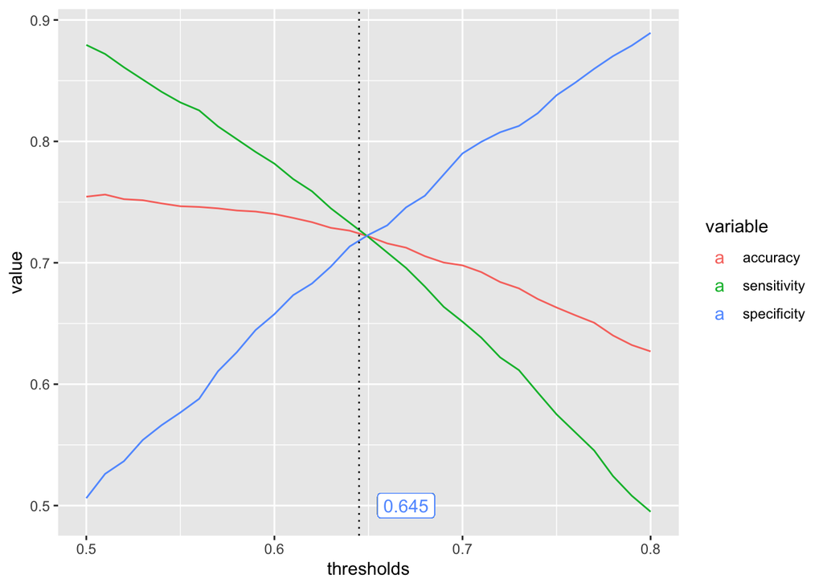

The optimal threshold for our aim is 0.645.  
This threshold meets our expectations, as the equilibrium point corresponds to a value higher than 0.5.  
This higher threshold compensates for the higher a priori probability of labelling a wine as high quality (low: 1640, high: 3258).

### Model’s test performance

To evaluate the performance of the estimated model, we use the Confusion Matrix to compute the accuracy, sensitivity and specificity scores.

```
## $confusion
##         truth
## response high low
##     high  700 141
##     low   277 351
##
## $accuracy
## classif.acc
##   0.7154527
##
## $sensitivity
## classif.sensitivity
##            0.716479
##
## $specificity
## classif.specificity
##           0.7134146
```

We can state that:

- the model predicts wines quality with a 71.55% accuracy.
- 71.65% of wines are correctly identified as high quality wines.
- 71.34% of wines are correctly identified as low quality wines.

### Full/Restricted Performance comparison

In order to see how the model’s performance is affected by the dimensionality reduction, we compute the predictions for both the restricted and the full model and we compare the values of accuracy, sensitivity, and specificity. By removing 5 out of 11 explanatory variables we are trying to avoid overfitting, thus creating a more stable model with a lower variance; of course, we expect the performance to be slightly worse, as we are introducing some bias.

```
##             unrestr_performance restr_performance   difference
## Accuracy              0.7168142         0.7154527 -0.001361470
## Sensitivity           0.7175026         0.7164790 -0.001023541
## Specificity           0.7154472         0.7134146 -0.002032520
```

As expected there is a slight worsening in the model’s prediction accuracy, but this increase in bias is negligible with respect to the decrease in variance obtained with the simpler model.

## Model diagnostics

Once the model has been trained, we can perform some diagnostics to identify any possible issue with it.

### Multicollinearity

The Variance Inflation Factor measures how much the behaviour (variance) of an independent variable is influenced, or inflated, by its interaction/correlation with the other independent variables.  
Multicollinearity would not reduce the predictive power of the model, but it inflates the variance and thus the standard errors of the estimates, thus leading to wider confidence intervals, and less statistically reliable estimates.  
As a rule of thumb, we consider problematic those variables having the square root of VIF higher than 2.

```
##       fixed.acidity    volatile.acidity      residual.sugar free.sulfur.dioxide
##               FALSE               FALSE               FALSE               FALSE
##           sulphates             alcohol
##               FALSE               FALSE
```

By checking the VIF after the removal of the variable “density” we can confirm that no other variable is influenced by the others.

### Detecting outliers

Outliers and high leverage points may distort the outcome and accuracy of our logistic regression.  
In order to find influential outliers we use the Cook’s Distance, which measures how much deleting each given observation affects the fitted values of the model.  
As a general rule of thumb, the observations with a Cook’s Distance higher than 4/(N-k-1) are possible outliers, where N is the number of observations and k is the number of covariates.  
Even if Cook’s distance can suffer from a masking effect, for the scope of this project we will still use it for simplicity.

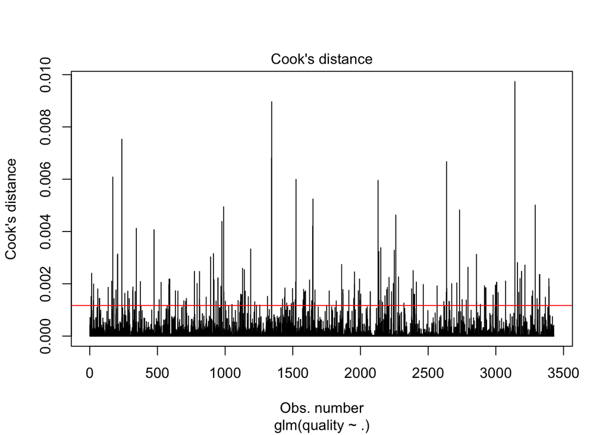

We remove the observations with a Cook’s Distance larger than the defined threshold and inspect the plot again, to see the variability of the remaining computed distances.

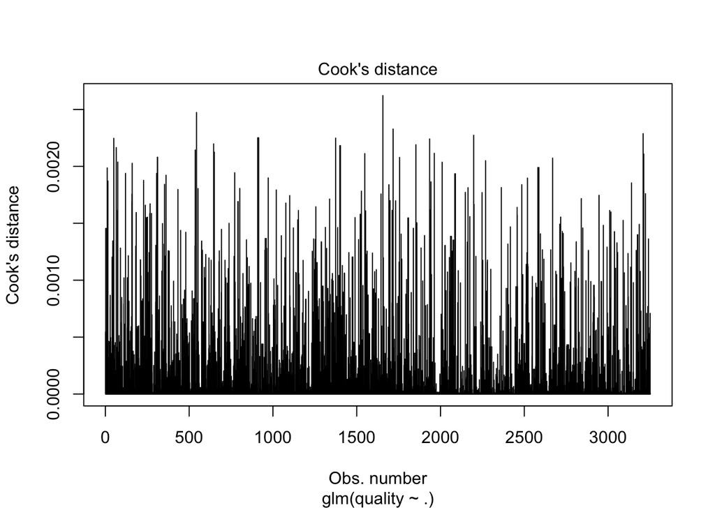

From this second plot we can see that the Cook’s distances are now within an acceptable range of variability.

## Outliers free model

Now, we build a new model without the outlying observations. We will then compare the estimated coefficents and the performance with the previous model.

### Threshold tuning

We perform threshold tuning again for the new outliers free model.

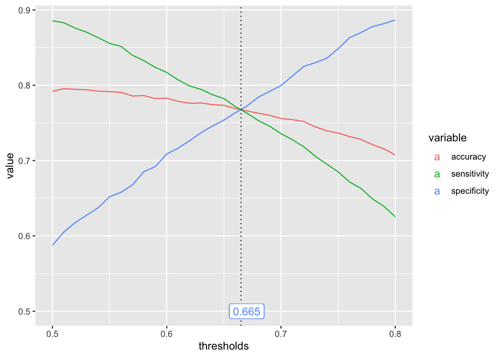

### Change in performance

It is interesting to compare the test performance before and after the outliers removal. We expect the new robust model to be more accurate.

```
##             base_performance outliers_free_performance  difference
## Accuracy           0.7168142                 0.7272075  0.01039331
## Sensitivity        0.7175026                 0.7481081  0.03060555
## Specificity        0.7154472                 0.6858974 -0.02954972
```

After removing the outliers, the model has a higher overall accuracy on the test set.

### Estimated coefficients

To see the impact that the removed observation had on our estimated model, we can see how much the coefficients changed after we removed the outliers.  
The issue with outliers is in fact that they have a great influence on the estimation, as they mask the real effect of a feature on the probability of having a high quality wine.

```
##              variable base.Estimate no_outliers.Estimate  difference
## 1          (constant)  -8.592427884         -12.92996876  4.33754087
## 2       fixed.acidity  -0.199360575          -0.31999069  0.12063012
## 3    volatile.acidity  -6.839885959         -10.93252916  4.09264321
## 4      residual.sugar   0.069505651           0.10221810 -0.03271245
## 5 free.sulfur.dioxide   0.009150792           0.02035413 -0.01120334
## 6           sulphates   1.174703773           1.64265115 -0.46794737
## 7             alcohol   1.087649605           1.64143500 -0.55378540
```

We can notice that the coefficients are quite different after outliers removal, in particular those related to the constant, volatile acidity, sulphates and alcohol.  
However, no coefficient changes sign, meaning that the outliers were not influencing the direction of the effects, but only their entity.

# Bagging

- Accuracy: 72.94%
- Sensitivity: 75.46%
- Specificity: 67.95%

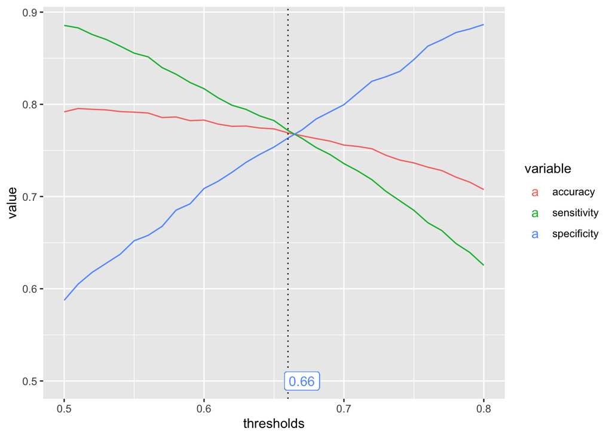

```
## Confusion Matrix and Statistics
##
##           Reference
## Prediction low high
##       low  318  227
##       high 150  698
##
##                Accuracy : 0.7294
##                  95% CI : (0.7052, 0.7525)
##     No Information Rate : 0.664
##     P-Value [Acc > NIR] : 8.734e-08
##
##                   Kappa : 0.4171
##
##  Mcnemar's Test P-Value : 9.070e-05
##
##             Sensitivity : 0.7546
##             Specificity : 0.6795
##          Pos Pred Value : 0.8231
##          Neg Pred Value : 0.5835
##              Prevalence : 0.6640
##          Detection Rate : 0.5011
##    Detection Prevalence : 0.6088
##       Balanced Accuracy : 0.7170
##
##        'Positive' Class : high
##
```

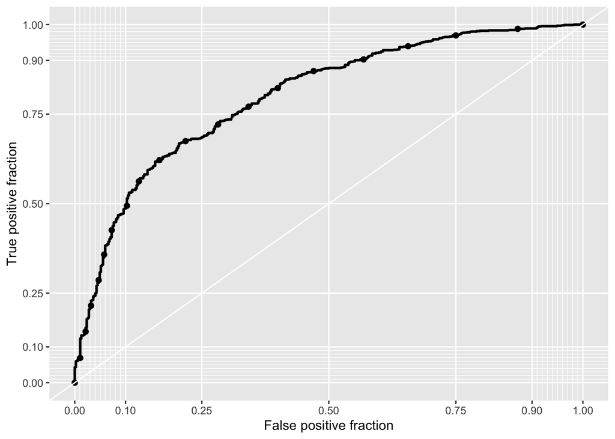

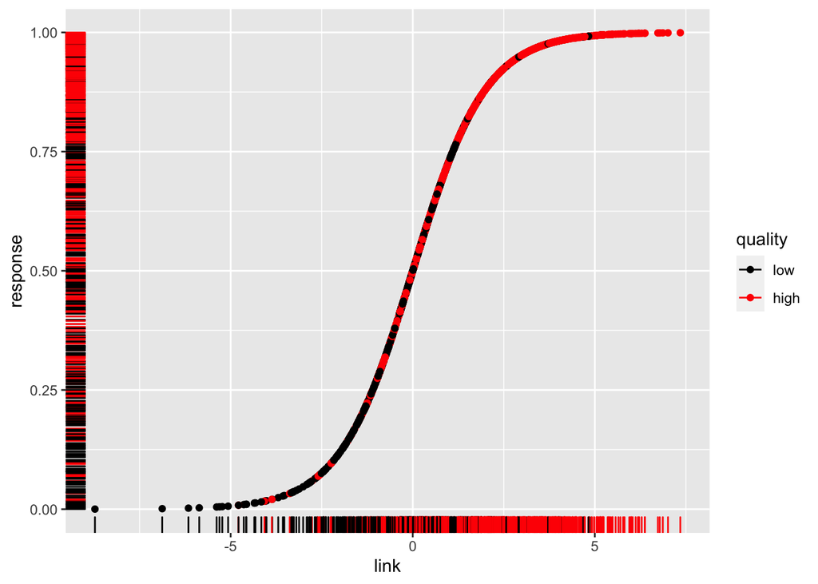